Let us consider the dataframe SAheart of the library ElemStatLearn, which comprises information about a retrospective sample of males in a heart-disease high-risk region of the Western Cape, South Africa. The help file and the output of the str command are given below

```
## 'data.frame':    462 obs. of  10 variables:
##  $ sbp      : int  160 144 118 170 134 132 142 114 114 132 ...
##  $ tobacco  : num  12 0.01 0.08 7.5 13.6 6.2 4.05 4.08 0 0 ...
##  $ ldl      : num  5.73 4.41 3.48 6.41 3.5 6.47 3.38 4.59 3.83 5.8 ...
##  $ adiposity: num  23.1 28.6 32.3 38 27.8 ...
##  $ famhist  : Factor w/ 2 levels "Absent","Present": 2 1 2 2 2 2 1 2 2 2 ...
##  $ typea    : int  49 55 52 51 60 62 59 62 49 69 ...
##  $ obesity  : num  25.3 28.9 29.1 32 26 ...
##  $ alcohol  : num  97.2 2.06 3.81 24.26 57.34 ...
##  $ age      : int  52 63 46 58 49 45 38 58 29 53 ...
##  $ chd      : int  1 1 0 1 1 0 0 1 0 1 ...
```

The aim of the study is to analyze the potential relationship between the binary response variable chd and the explanatory variables considered in the dataframe. Describe how to perform a preliminary data analysis on this dataframe, using suitable R commands, and comment the following plot.

### Distribuzione delle variabili

Dataset composto da 8 variabili numeriche e 2 categoriali. La variabile risposta è `chd` di tipo booleano.

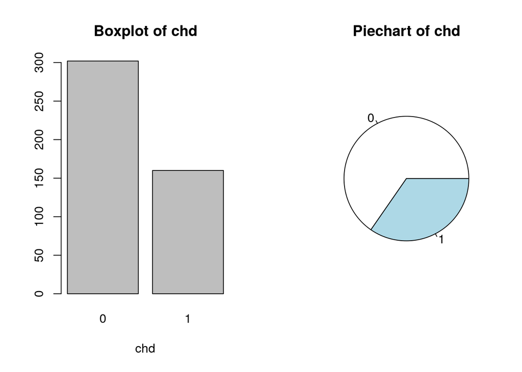

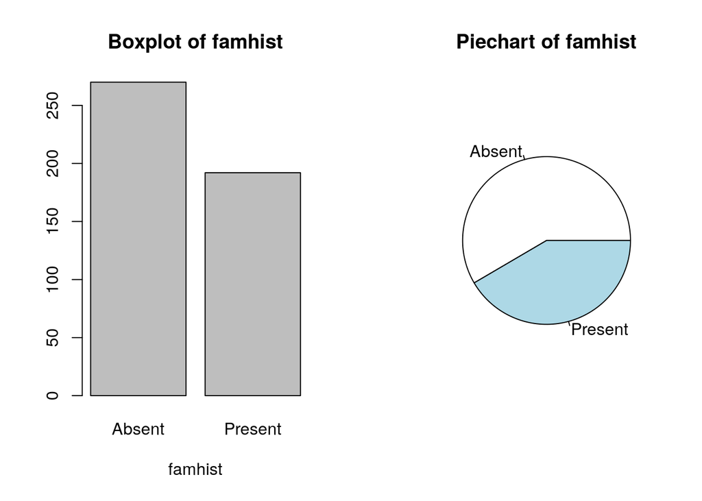

```r
source("./../functions.R", local = knitr::knit_global())

categorical.graph(data = SAheart, variables = c(10, 5))
```

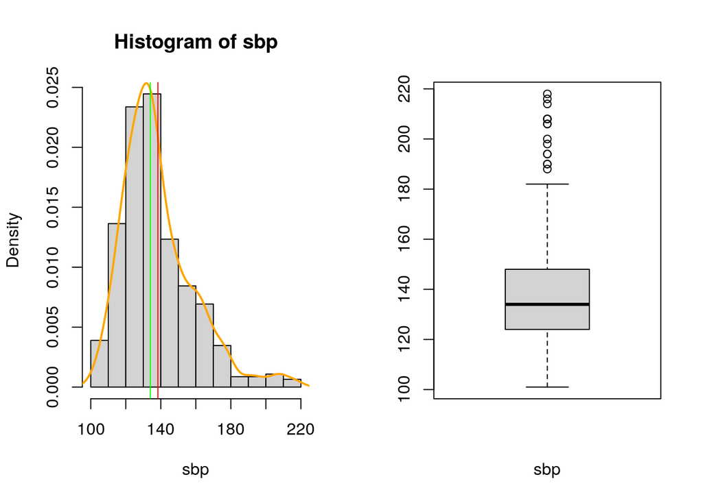

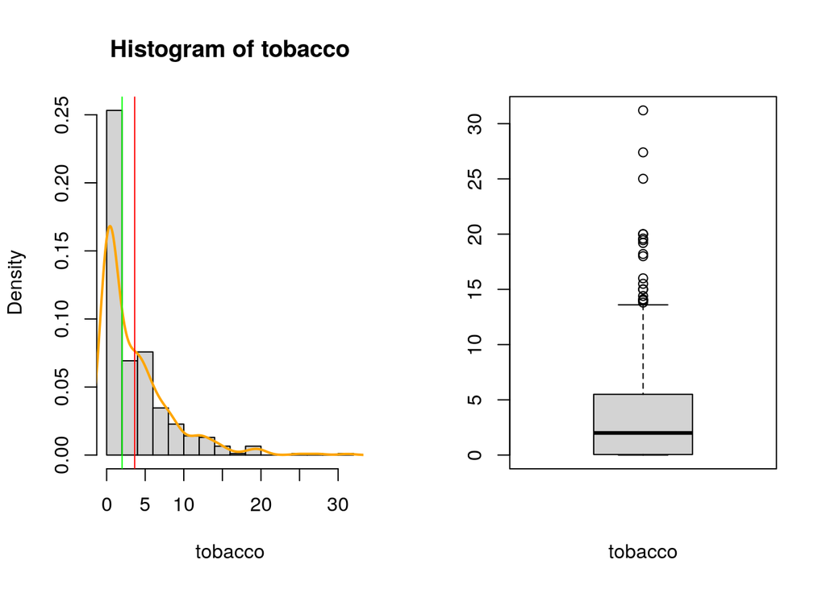

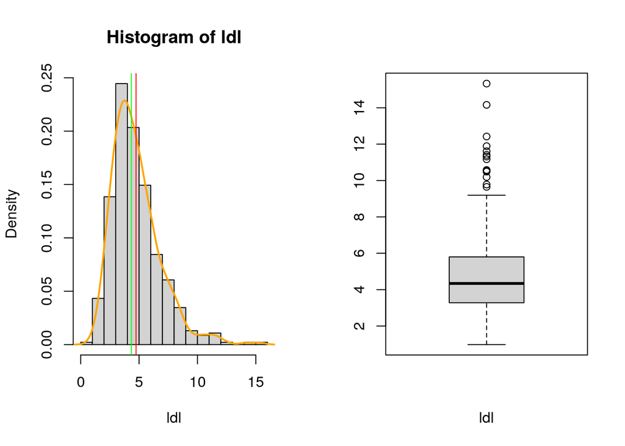

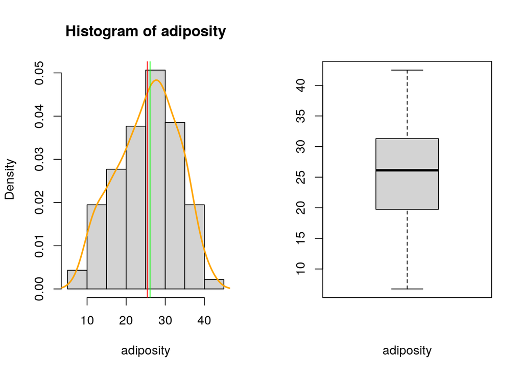

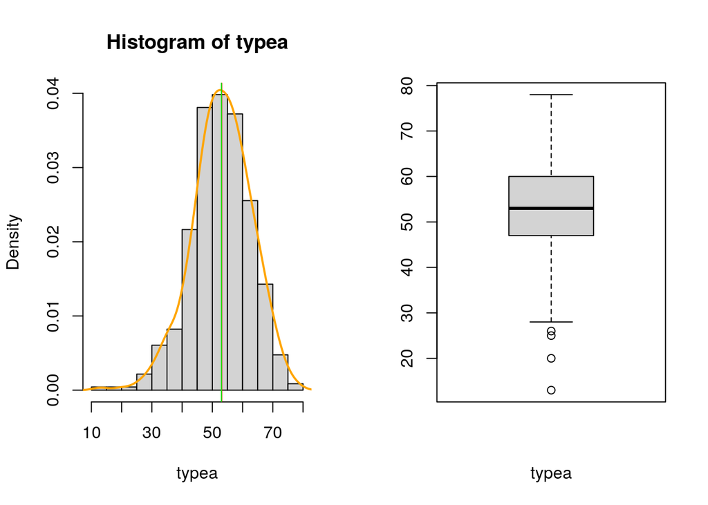

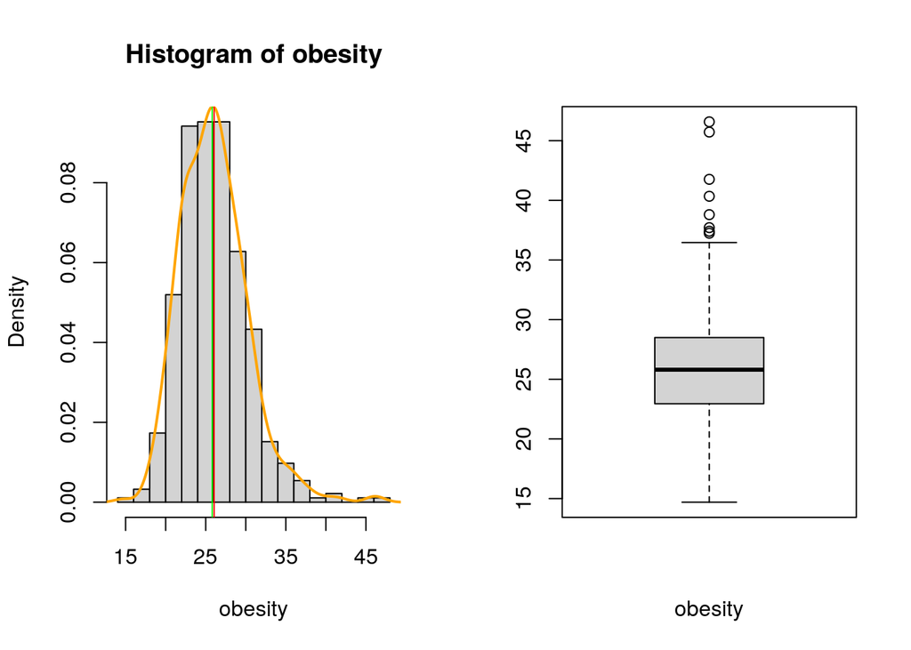

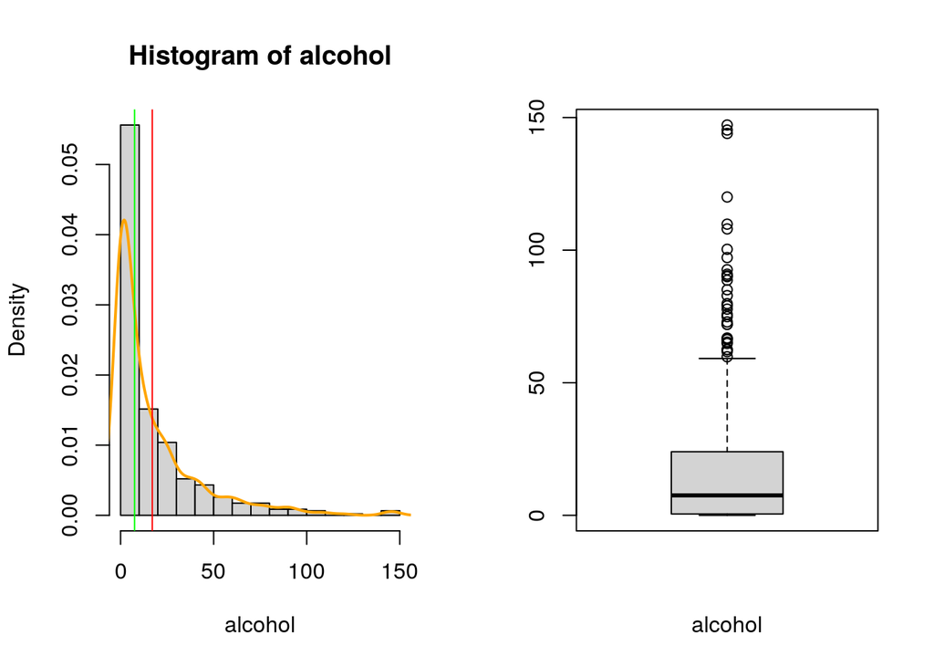

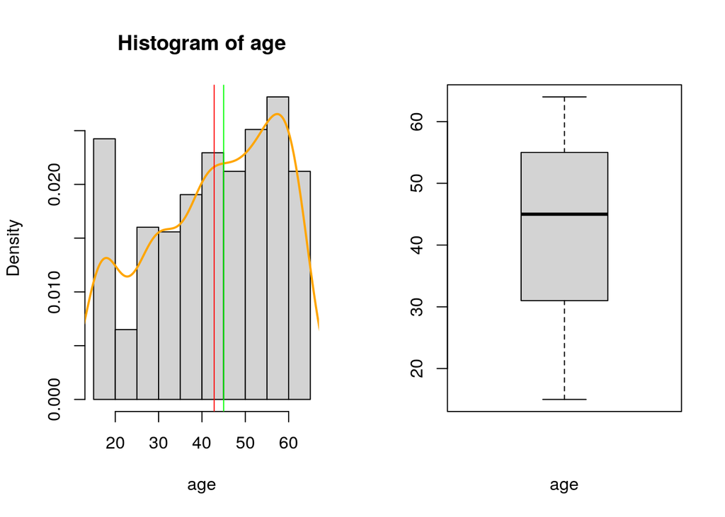

```
## [1] "Skewness indexes"
##        sbp    tobacco        ldl  adiposity      typea    obesity    alcohol
##  1.1767541  2.0724529  1.3088368 -0.2139484 -0.3453119  0.9022777  2.3051834
##        age
## -0.3804937
## [1] "Kurtosis indexes - 3"
##        sbp    tobacco        ldl  adiposity      typea    obesity    alcohol
##  1.7494640  5.8907544  2.8325566 -0.7038616  0.4523678  2.2186712  6.3388687
##        age
## -1.0182231
```

```r
numeric.graph(data = SAheart, variables = c(1,2,3,4,6,7,8,9))
```



### Relazioni tra variabili

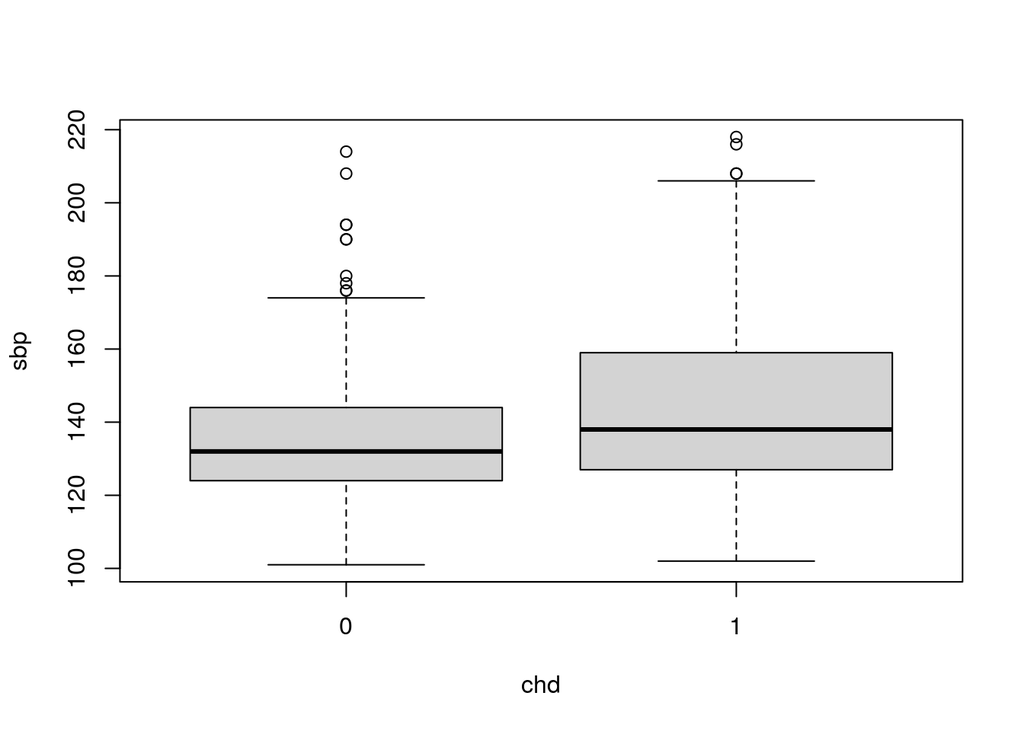

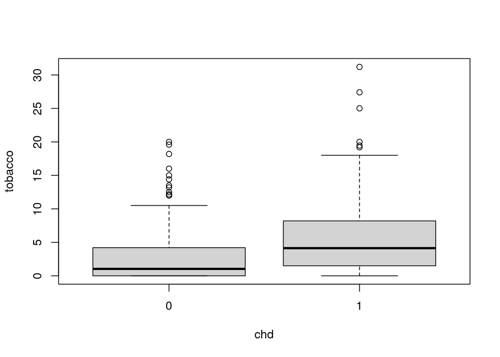

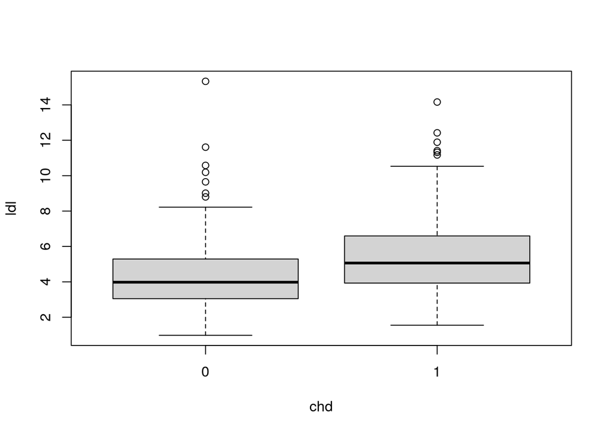

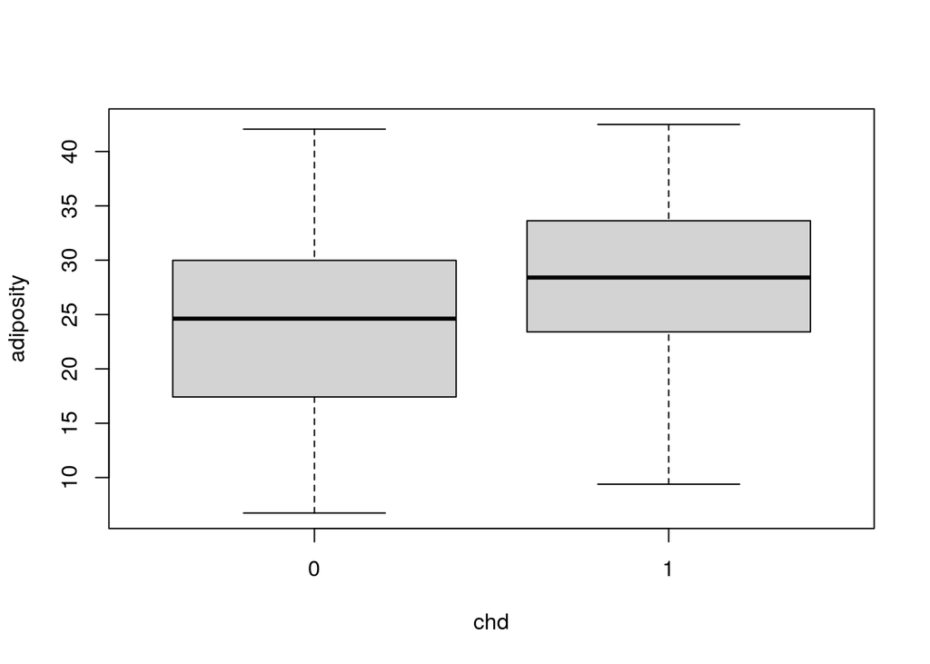

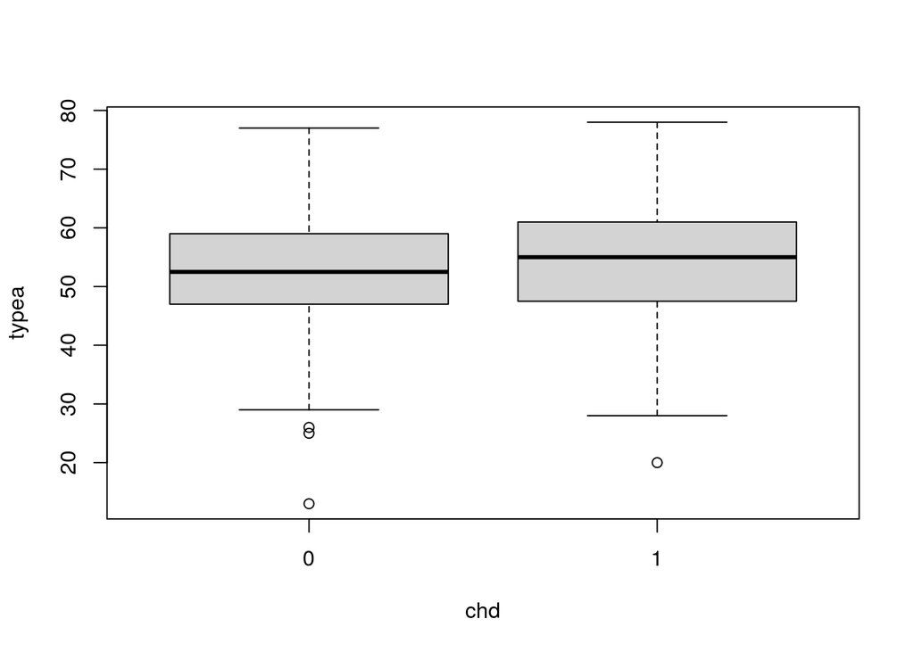

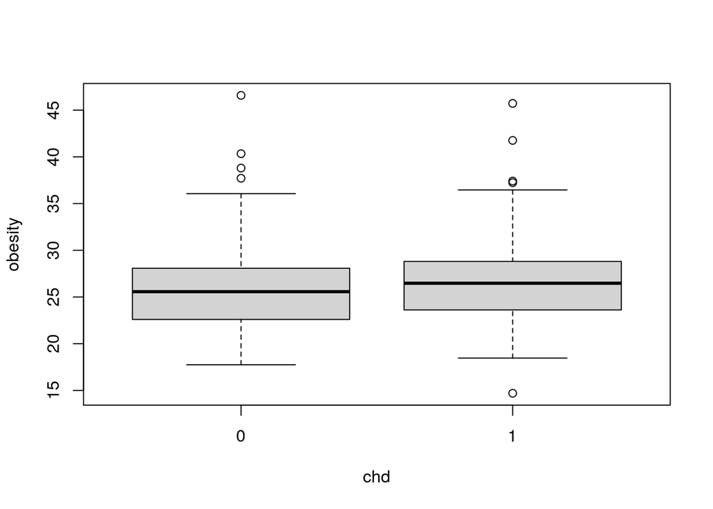

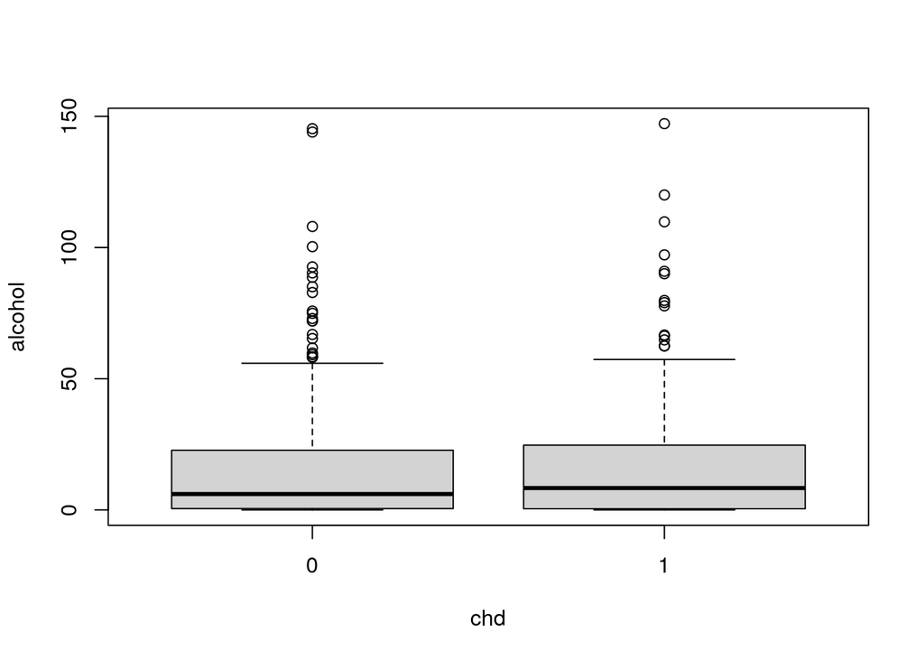

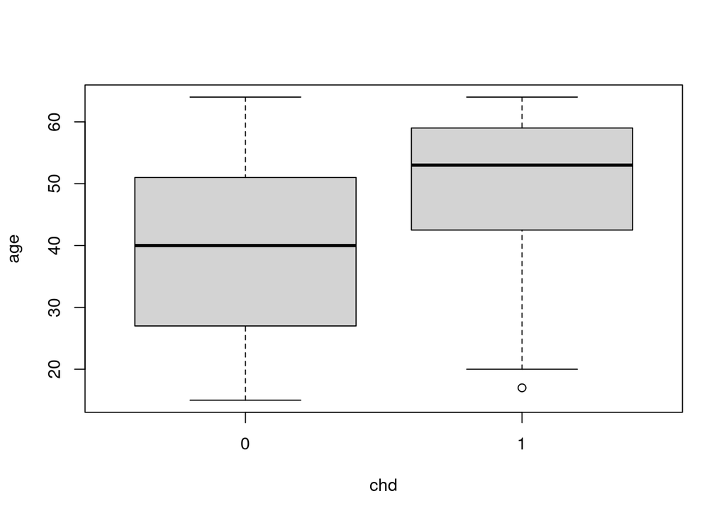

```r
logitResponse.numeric.graph(10, c(1,2,3,4,6,7,8,9), data = SAheart)
```

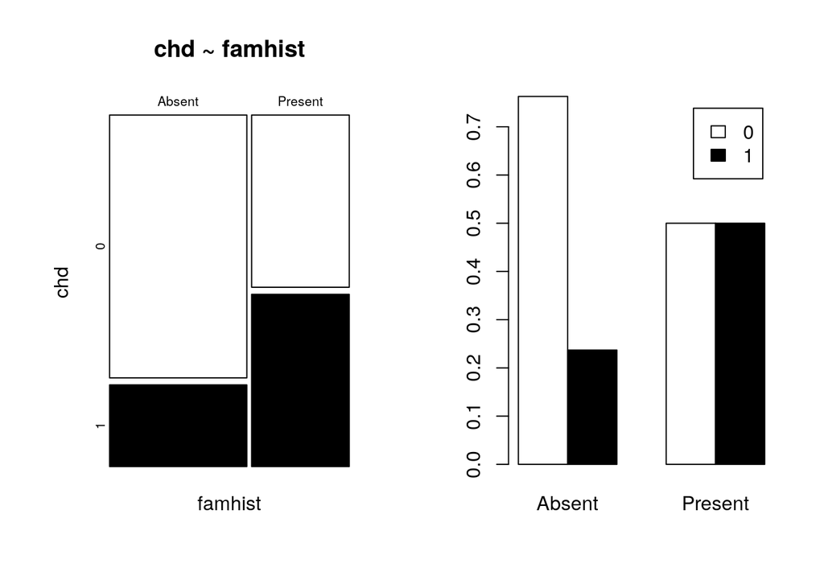

```r
logitResponse.categorical.graph(10, c(5), data = SAheart)
```

#### Osservazioni

With the command `mod0 <- glm(chd ∼ ldl, data = SAheart, family = binomial)`, a simple logistic regression model is defined for describing the potential effect of the level of ldl on the probability of coronary heart disease. Comment the model fitting outcomes given by the function summary.

```
##
## Call:
## glm(formula = chd ~ ldl, family = binomial, data = SAheart)
##
## Deviance Residuals:
##     Min       1Q   Median       3Q      Max
## -2.1647  -0.8948  -0.7426   1.2688   1.8637
##
## Coefficients:
##             Estimate Std. Error z value Pr(>|z|)
## (Intercept) -1.96867    0.27308  -7.209 5.63e-13 ***
## ldl          0.27466    0.05164   5.319 1.04e-07 ***
## ---
## Signif. codes:  0 '***' 0.001 '**' 0.01 '*' 0.05 '.' 0.1 ' ' 1
##
## (Dispersion parameter for binomial family taken to be 1)
##
##     Null deviance: 596.11  on 461  degrees of freedom
## Residual deviance: 564.28  on 460  degrees of freedom
## AIC: 568.28
##
## Number of Fisher Scoring iterations: 4
```

Da questo modello risulta che ldl è un regressore significativo per chd e che un aumento di questo valore corrisponde anche a un aumento della probabilità di chd.

After fitting these two further logistic regression models `mod1 <- glm(chd ∼ ., data = SAheart, family = binomial)` and `mod2 <- glm(chd ∼ tobacco + ldl + famhist + typea + age + ldl:famhist, data = SAheart, family = binomial)`, the following outputs are obtained by the R function summary. Describe how to interpret these results, and then suggest how to proceed with further analyses.

```
##
## Call:
## glm(formula = chd ~ ., family = binomial, data = SAheart)
##
## Deviance Residuals:
##     Min       1Q   Median       3Q      Max
## -1.7781  -0.8213  -0.4387   0.8889   2.5435
##
## Coefficients:
##                  Estimate Std. Error z value Pr(>|z|)
## (Intercept)    -6.1507209  1.3082600  -4.701 2.58e-06 ***
## sbp             0.0065040  0.0057304   1.135 0.256374
## tobacco         0.0793764  0.0266028   2.984 0.002847 **
## ldl             0.1739239  0.0596617   2.915 0.003555 **
## adiposity       0.0185866  0.0292894   0.635 0.525700
## famhistPresent  0.9253704  0.2278940   4.061 4.90e-05 ***
## typea           0.0395950  0.0123202   3.214 0.001310 **
## obesity        -0.0629099  0.0442477  -1.422 0.155095
## alcohol         0.0001217  0.0044832   0.027 0.978350
## age             0.0452253  0.0121298   3.728 0.000193 ***
## ---
## Signif. codes:  0 '***' 0.001 '**' 0.01 '*' 0.05 '.' 0.1 ' ' 1
##
## (Dispersion parameter for binomial family taken to be 1)
##
##     Null deviance: 596.11  on 461  degrees of freedom
## Residual deviance: 472.14  on 452  degrees of freedom
## AIC: 492.14
##
## Number of Fisher Scoring iterations: 5
```

Modello di regressione logistico con tutte le variabili esplicative. Si nota che non tutti i regressori sono significativi, in particolare alcohol, adiposity e sbp.

Il regressore più significativo è `famhist` con valore positivo (la presenza di persone con chd in famiglia aumenta la probabilità di avere chd a sua volta).

Si nota però una netta riduzione sia dell’indice AIC che della devianza residua rispetto al modello `mod0`.

```r
mod2 <- glm(chd ~ tobacco + ldl + famhist + typea + age + ldl:famhist, data = SAheart, family = binomial)
summary(mod2)
```

```
##
## Call:
## glm(formula = chd ~ tobacco + ldl + famhist + typea + age + ldl:famhist,
##     family = binomial, data = SAheart)
##
## Deviance Residuals:
##     Min       1Q   Median       3Q      Max
## -1.8463  -0.7938  -0.4419   0.9161   2.4956
##
## Coefficients:
##                    Estimate Std. Error z value Pr(>|z|)
## (Intercept)        -5.79224    0.94625  -6.121 9.28e-10 ***
## tobacco             0.08496    0.02628   3.233  0.00122 **
## ldl                 0.01758    0.07302   0.241  0.80974
## famhistPresent     -0.77068    0.62341  -1.236  0.21637
## typea               0.03690    0.01240   2.974  0.00294 **
## age                 0.05140    0.01030   4.990 6.03e-07 ***
## ldl:famhistPresent  0.33334    0.11595   2.875  0.00404 **
## ---
## Signif. codes:  0 '***' 0.001 '**' 0.01 '*' 0.05 '.' 0.1 ' ' 1
##
## (Dispersion parameter for binomial family taken to be 1)
##
##     Null deviance: 596.11  on 461  degrees of freedom
## Residual deviance: 466.90  on 455  degrees of freedom
## AIC: 480.9
##
## Number of Fisher Scoring iterations: 5
```

I regressori meno significativi sono ldl e famihst, tuttavia la loro interazione è significativa e con effetto positivo.

Infatti, rispetto a `mod1`, famhistPresent cambia di segno, il che significa che nelle famiglie con persone aventi chd al suo interno il valore di ldl tende ad essere leggermente più elevato. Questa impressione è verificabile dal boxplot delle due variabili:

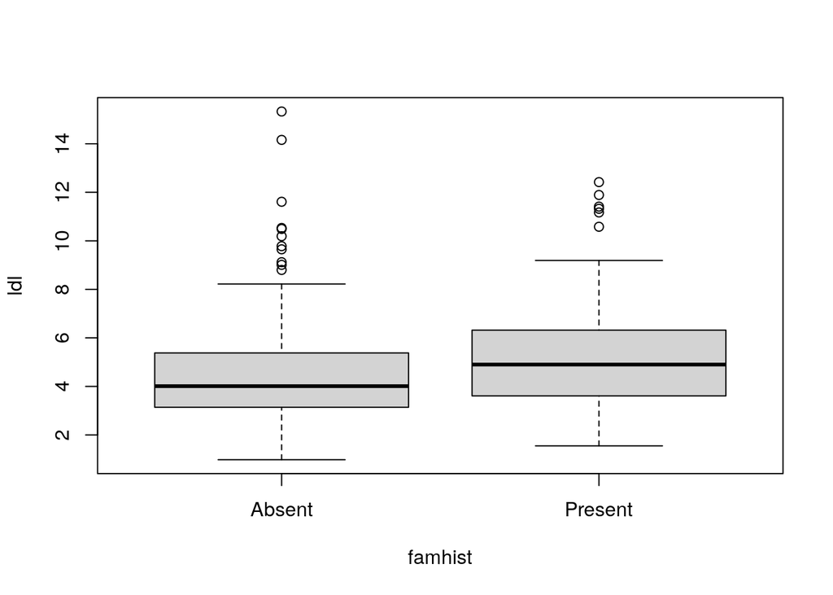

```r
boxplots.graph(3, 5, data = SAheart)
```

### Verifica di correttezza e accuratezza del modello `mod2`

```r
logitResponse.modelVerify(mod2, 10)
```

```
## [1] "Il modello è corretto, tutti i fitted values sono compresi tra 0 e 1"
```

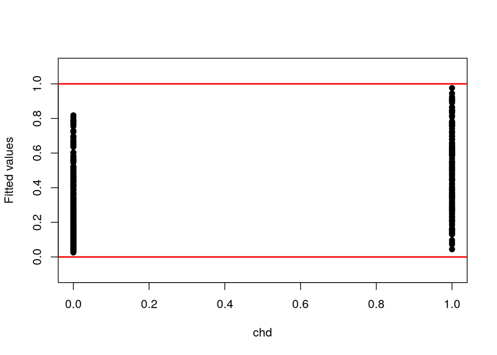

```
##
## Fold:  6 2 1 7 10 3 5 9 4 8
## Internal estimate of accuracy = 0.758
## Cross-validation estimate of accuracy = 0.749
```

Il livello di accuratezza è buono, ma non troppo elevato. Non ci sono problemi di overfitting (la stima di accuratezza interna e cross-validata è molto simile).